# Design de Jukeboxes - Baseline x Mecanismos

### Baseline x skip

Queremos comparar a diferença média entre a satisfação usando a jukebox sem funcionalidades e a satisfação usando a função de skip (pular musica) . Dito isso, o objetivo é investigar se é e quanto é plausível dizer, em média, que skip é preferível a função nenhuma.

Primeiro vamos observar a faixa de valores que zero funcionalidade possui. Para isso, plotaremos o nível de satisfação por usuário.

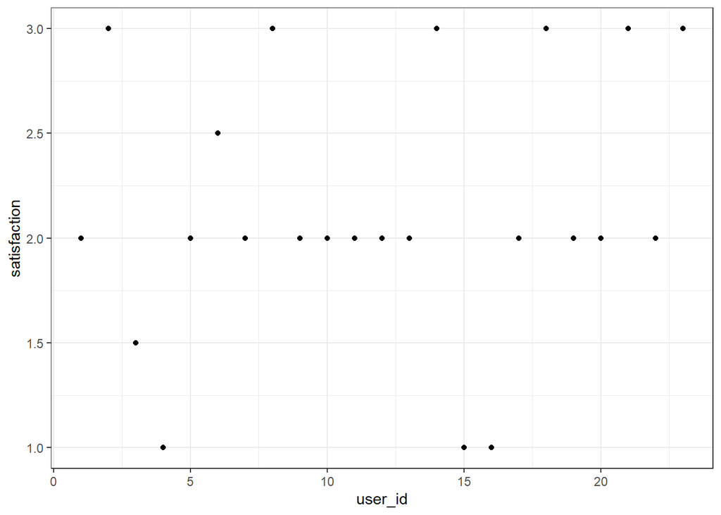

```r
jukebox %>%
filter(scenario == "baseline") %>%
ggplot(aes(user_id,satisfaction))+
geom_point()
```

A maioria deles tem nota 2 e 3. Além disso, em uma escala de 1 a 5, nenhuma das avaliações supera nota 3.

E enquanto a faixa de valores para a funcao de skip?

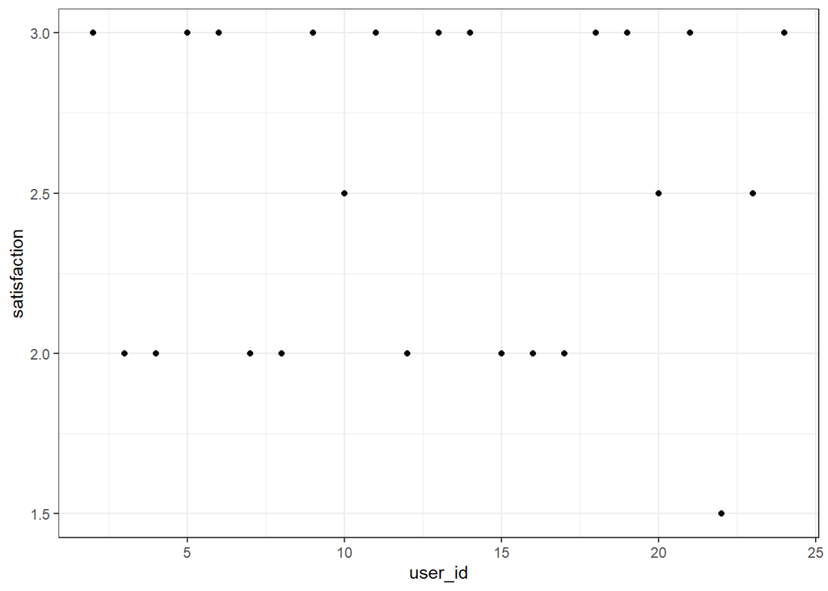

```r
jukebox %>%
filter(scenario == "skip") %>%
ggplot(aes(user_id,satisfaction))+
geom_point()
```

Nesse caso a faixa está centrada entre 2 e 3 com a maioria dos pontos em 2 e 3, ou seja, aparentemente as funcionalidades tem satisfações parecidas.

Queremos verificar agora, a partir dos resultados dessa amostra, para uma população qualquer, qual é uma provavél faixa da diferença média de satisfação entre esses dois mecanismos.

Para isso usaremos a tecnica de bootstrapping na amostra com o intuito de gerar novas amostras aleatórias, dessa forma, podemos inferir informações da população a partir do que temos.

```r
theta = function(d,i){

    juke = d %>%
    slice(i) %>%
    group_by(scenario) %>%
    summarise(media = mean(satisfaction))

    baseline = juke %>%
    filter(scenario == "baseline") %>%
    pull(media)

    skip = juke %>%
    filter(scenario == "skip") %>%
    pull(media)

    skip - baseline

}


jukebox %>%
boot(statistic = theta,R = 4000) %>%
tidy(conf.level = 0.95,conf.int = TRUE)
```

| statistic | bias | std.error | conf.low | conf.high |
| --- | --- | --- | --- | --- |
| 0.3913043 | 0.004417185 | 0.1711873 | 0.05966765 | 0.7367687 |

Como a diferença calculada foi skip - baseline(sem funcionalidades), quer dizer que: quanto mais positiva essa diferença, maior a preferência média pela funcão skip(pular faixa).

Com base nos cáculos, com 95% de confiança, é plausível afirmar que a diferença média entre a satisfação da funcionalidade skip e nenhuma funcionalidade varia entre 0.05 e 0.73. Ou seja, pode-se dizer que não é um absurdo alegar que a funcionalidade skip é preferível a nenhuma funcionalidade.

Tendo em vista que os níveis de satisfação variam de 1 a 5, podemos ver que a diferença média desses dois mecanismos é consideravelmente pequena, pois até o limite superior da faixa é menor que 1 ponto.

```r
medias = jukebox %>%
group_by(scenario) %>%
summarise(media = mean(satisfaction))

skip = medias %>%
filter(scenario == "skip") %>%
pull(media)

baseline = medias %>%
filter(scenario == "baseline") %>%
pull(media)

theta_r = skip - baseline
```

```r
#modelo nulo - Não existe diferença entre os dois grupos.

um_embaralhamento = function(d){

  d %>%
  mutate(embaralhado = sample(scenario,n())) %>%
  group_by(embaralhado) %>%
  summarise(media = mean(satisfaction)) %>%
  summarise(dif = diff(media)) %>%
  pull(dif)

}
```

```r
d = jukebox %>%
filter(scenario == "skip" | scenario == "baseline")

modelo_nulo = tibble(diferenca = replicate(1000,{um_embaralhamento(d)}))

modelo_nulo %>%
mutate(igual_maior =  abs(diferenca)>= theta_r) %>%
summarise(p_valor = sum(igual_maior)/n())
```

| p_valor |
| --- |
| 0.035 |

Estimamos que há uma diferença estatisticamente significativa entre baseline e skip (theta_c = 0.3913, n = 23, p = 0.035).

### Baseline x like/dislike

Queremos comparar a diferença média entre a satisfação usando a jukebox sem funcionalidades e a satisfação usando a função de like/dislike . Dito isso, o objetivo é investigar se é e quanto é plausível dizer, em média, que like/dislike é preferível a função nenhuma.

Vejamos a faixa de valores para a funcao de like/dislike

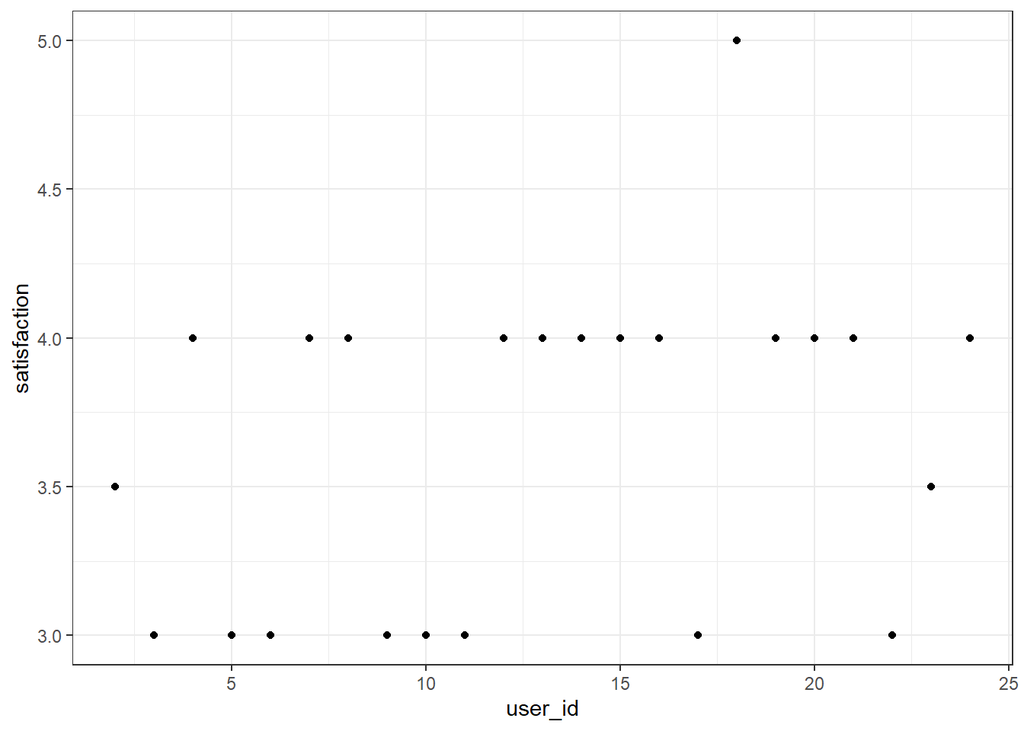

```r
jukebox %>%
filter(scenario == "like/dislike") %>%
ggplot(aes(user_id,satisfaction))+
geom_point()
```

Nesse caso a faixa está centrada entre 3 e 5 com a maioria dos pontos em 3 e 4, ou seja, like/dislike parece ser bem melhor avaliada que baseline.

Aplicando bootstrapping:

```r
theta = function(d,i){

    juke = d %>%
    slice(i) %>%
    group_by(scenario) %>%
    summarise(media = mean(satisfaction))

    baseline = juke %>%
    filter(scenario == "baseline") %>%
    pull(media)

    like = juke %>%
    filter(scenario == "like/dislike") %>%
    pull(media)

    like - baseline

}


jukebox %>%
boot(statistic = theta,R = 4000) %>%
tidy(conf.level = 0.95,conf.int = TRUE)
```

| statistic | bias | std.error | conf.low | conf.high |
| --- | --- | --- | --- | --- |
| 1.521739 | -0.003442966 | 0.180742 | 1.164914 | 1.88 |

Como a diferença calculada foi like - baseline(sem funcionalidades), quer dizer que: quanto mais positiva essa diferença, maior a preferência média pela funcão like/dislike.

Tendo em vista que os níveis de satisfação variam de 1 a 5, podemos ver que a diferença média desses dois mecanismos é expressiva, pois toda a faixa indica pelo menos 1 ponto de diferença.

```r
medias = jukebox %>%
group_by(scenario) %>%
summarise(media = mean(satisfaction))

like = medias %>%
filter(scenario == "like/dislike") %>%
pull(media)

baseline = medias %>%
filter(scenario == "baseline") %>%
pull(media)

theta_r = like - baseline
```

```r
d = jukebox %>%
filter(scenario == "like/dislike" | scenario == "baseline")

modelo_nulo = tibble(diferenca = replicate(1000,{um_embaralhamento(d)}))

modelo_nulo %>%
mutate(igual_maior =  abs(diferenca)>= theta_r) %>%
summarise(p_valor = sum(igual_maior)/n())
```

| p_valor |
| --- |
| 0 |

Estimamos que há uma diferença estatisticamente significativa entre baseline e like/dislike (theta_c = 1.52, n = 23, p = 0).

### Baseline x up/downvoting

Queremos comparar a diferença média entre a satisfação usando a jukebox sem funcionalidades e a satisfação usando a função de up/downvoting . Dito isso, o objetivo é investigar se é e quanto é plausível dizer, em média, que up/downvoting é preferível a função nenhuma.

Vejamos a faixa de valores para a funcao de up/downvoting

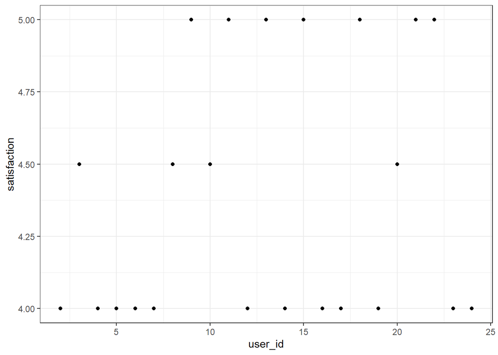

```r
jukebox %>%
filter(scenario == "up/downvoting") %>%
ggplot(aes(user_id,satisfaction))+
geom_point()
```

Nesse caso a faixa está centrada entre 4 e 5 com a maioria dos pontos em 4 e 5, ou seja, up/downvoting parece ser extremamente melhor avaliada que baseline.

Aplicando bootstrapping:

```r
theta = function(d,i){

    juke = d %>%
    slice(i) %>%
    group_by(scenario) %>%
    summarise(media = mean(satisfaction))

    baseline = juke %>%
    filter(scenario == "baseline") %>%
    pull(media)

    up = juke %>%
    filter(scenario == "up/downvoting") %>%
    pull(media)

    up - baseline

}


jukebox %>%
boot(statistic = theta,R = 4000) %>%
tidy(conf.level = 0.95,conf.int = TRUE)
```

| statistic | bias | std.error | conf.low | conf.high |
| --- | --- | --- | --- | --- |
| 2.26087 | -0.0008004408 | 0.1608679 | 1.945035 | 2.575 |

Como a diferença calculada foi up - baseline(sem funcionalidades), quer dizer que: quanto mais positiva essa diferença, maior a preferência média pela funcão up/downvoting.

Tendo em vista que os níveis de satisfação variam de 1 a 5, podemos ver que a diferença média desses dois mecanismos é extrema, pois a faixa se mantem na região de dois a dois e meio pontos de diferença.

```r
medias = jukebox %>%
group_by(scenario) %>%
summarise(media = mean(satisfaction))

up = medias %>%
filter(scenario == "up/downvoting") %>%
pull(media)

baseline = medias %>%
filter(scenario == "baseline") %>%
pull(media)

theta_r = up - baseline
```

```r
d = jukebox %>%
filter(scenario == "up/downvoting" | scenario == "baseline")

modelo_nulo = tibble(diferenca = replicate(1000,{um_embaralhamento(d)}))

modelo_nulo %>%
mutate(igual_maior =  abs(diferenca)>= theta_r) %>%
summarise(p_valor = sum(igual_maior)/n())
```

| p_valor |
| --- |
| 0 |

Estimamos que há uma diferença estatisticamente significativa entre baseline e up/downvoting (theta_c = 2.26, n = 23, p = 0).

### Baseline x combined

Queremos comparar a diferença média entre a satisfação usando a jukebox sem funcionalidades e a satisfação usando todas as funções . Dito isso, o objetivo é investigar se é e quanto é plausível dizer, em média, que combined é preferível a função nenhuma.

Vejamos a faixa de valores para a funcao combined

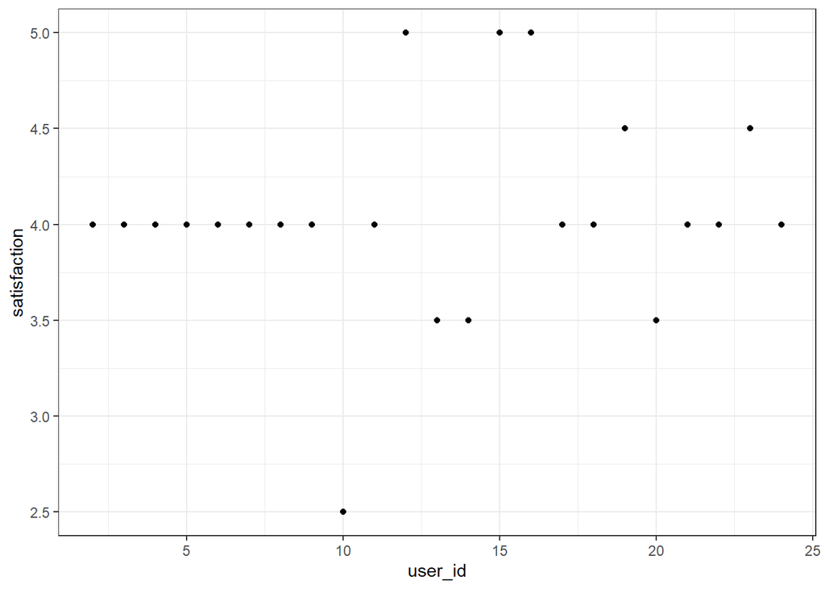

```r
jukebox %>%
filter(scenario == "combined") %>%
ggplot(aes(user_id,satisfaction))+
geom_point()
```

Nesse caso a faixa está centrada entre 3 e 5 com a maioria dos pontos em 4, ou seja, combined parece ser bem melhor avaliada que baseline.

Aplicando bootstrapping:

```r
theta = function(d,i){

    juke = d %>%
    slice(i) %>%
    group_by(scenario) %>%
    summarise(media = mean(satisfaction))

    baseline = juke %>%
    filter(scenario == "baseline") %>%
    pull(media)

    combined = juke %>%
    filter(scenario == "combined") %>%
    pull(media)

    combined - baseline

}


jukebox %>%
boot(statistic = theta,R = 4000) %>%
tidy(conf.level = 0.95,conf.int = TRUE)
```

| statistic | bias | std.error | conf.low | conf.high |
| --- | --- | --- | --- | --- |
| 1.913043 | 0.001354692 | 0.177759 | 1.559772 | 2.26222 |

Como a diferença calculada foi combined - baseline(sem funcionalidades), quer dizer que: quanto mais positiva essa diferença, maior a preferência média pela funcão combined.

```r
medias = jukebox %>%
group_by(scenario) %>%
summarise(media = mean(satisfaction))

combined = medias %>%
filter(scenario == "combined") %>%
pull(media)

baseline = medias %>%
filter(scenario == "baseline") %>%
pull(media)

theta_r = combined - baseline
```

```r
d = jukebox %>%
filter(scenario == "combined" | scenario == "baseline")

modelo_nulo = tibble(diferenca = replicate(1000,{um_embaralhamento(d)}))

modelo_nulo %>%
mutate(igual_maior =  abs(diferenca)>= theta_r) %>%
summarise(p_valor = sum(igual_maior)/n())
```

| p_valor |
| --- |
| 0 |